# Predict the Weather

9/18/2021

```r
# Adding equation and R^2 to line
lm_eq <- function(df){

    m <- lm(HighTempTarget ~ predictor, df)
    eq <- substitute(y == a + b (x)*","~~r^2~"="~r2,
         list(a = format(unname(coef(m)[1]), digits = 4),
              b = format(unname(coef(m)[2]), digits = 4),
             r2 = format(summary(m)$r.squared, digits = 3)))

    as.character(as.expression(eq))

}

plot <- plot +
  geom_text(x = 12, y = 60, label = lm_eq(regression_data), parse = TRUE)
```

```r
# Making Prediction

High <- ((77.3 - 59.333)/(86 - 59.333))*10
Temp <- ((60.39 - 50.14361)/(67.89855 - 50.14361))*10
Press <- ((29.92268 - 29.81341)/(30.10472 - 29.81341))*10
Hum <- ((0.39172 - 0.41636)/(0.7004216 - 0.41636))*10

pred <- (((1/summary(HighLM)$coefficients[,4][2])*High) + ((1/summary(TempLM)$coefficients[,4][2])*Temp)+((1/summary(PressLM)$coefficients[,4][2])*Press)+((1/summary(HumLM)$coefficients[,4][2])*Hum))/4

value <- predict(mainLM, data.frame(predictor = pred))
```

## What will the High Temperature be on September 20, 2021?

On September 20, 2021 I predict that the high temperature will be $70.03$ degrees.

Here is the linear model I created to predict the high temperature based a scaled predictor variable passed through a function that is weighted off of several variables based on their correlation.

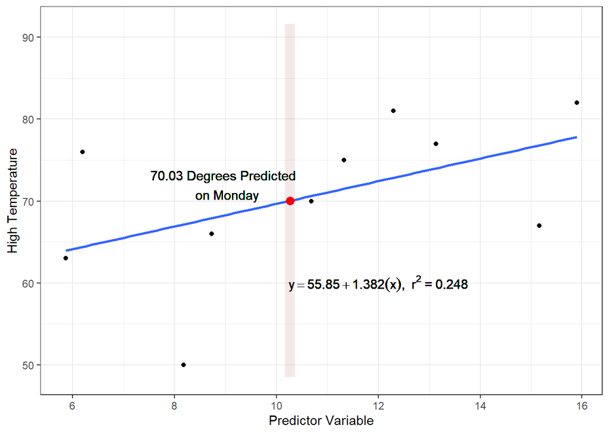

```r
pred <- predict(mainLM, data.frame(predictor = 10.27), interval = "prediction")

plot +
  theme_bw()+
  labs(x = "Predictor Variable",
       y = "High Temperature")+
  geom_point(aes(x = 10.27, y=70.03), size = 3, color = "red")+
  geom_text(label = "70.03 Degrees Predicted \n on Monday", aes(x = 9, y = 72))+
  geom_segment(aes(x = 10.27, xend = 10.27, y = pred[2], yend = pred[3]), size = 4, color = "firebrick", alpha = 0.01)
```

I will explain:

## Technical Summary

### Creating the Predictor Variable

Because there are many nuances associated with predicting weather a single variable would not suffice in order to predict the high temperature on Monday. As a result I created a variable based off of the the average high temperature, temperature, pressure, and humidity over the course of September 16-18 from the years 2011-2020. Each of these values were normalized using the function below:

$$Y = (\frac{X - X_{min}}{X_{range}})n$$

X is the variable, X_min is the smallest value in the feature, X_range is the difference between the minimum and the maximum value in the set, and n is the maximum value being scaled to.

Once the values were re-scaled a weighted mean was performed with the weights being a fraction of 1 over the p-value of the linear model p-value of the re-scaled variable. The formula looks as follows with X being the feature variables, i representing the number of features, and p representing the p-value of the feature:

$$f(x) = \frac{\sum_{i = 1}^{i}\frac{1}{p_i}x_i}{\sum_{i=1}^{i}1}$$

By plugging in the three day numbers on the day prior, I then got the predictor variable that could then be passed through the regression model.

In this case our predictor variable was 10.27.

### Analysis Details

The following was the output of the linear regression:

```r
pander(summary(mainLM))
```

|  | Estimate | Std. Error | t value | Pr(>\|t\|) |
| --- | --- | --- | --- | --- |
| **(Intercept)** | 55.85 | 9.563 | 5.84 | 0.0003874 |
| **predictor** | 1.382 | 0.8506 | 1.625 | 0.1428 |

Fitting linear model: HighTempTarget ~ predictor

| Observations | Residual Std. Error | $R^2$ | Adjusted $R^2$ |
| --- | --- | --- | --- |
| 10 | 8.906 | 0.2482 | 0.1543 |

The hypothesis test is as follows:

$$H_0: \beta_1 = 0$$

$$H_a: \beta_1 \neq 0$$

The model for the true line $Y_i$ is as follows:

$$\underbrace{Y_i}_\text{High Temperature} = \overbrace{\beta_0}^\text{y-int} + \overbrace{\beta_1}^\text{slope} \underbrace{X_i}_\text{Predictor Variable} + \epsilon_i \quad \text{where} \ \epsilon_i \sim N(0, \sigma^2)$$

After performing the regression, we can make a prediction of the true line $\hat{Y}_i$ is as follows:

$$\underbrace{\hat{Y}_i}_\text{Pred. High Temp} = 55.85 + 1.382 \underbrace{X_i}_\text{Predictor Variable}$$

As we can see, the relationship is not significantly strong (p = 0.1428), however there does seem to be a slight positive correlation. The meaningfulness is questionable.

Assuming that this is an appropriate model, as the predictor variable increases by one unit, the average high temperature will increase by 1.38 degrees Fahrenheit. Because the predictor variable is unlikely to have a value of 0 because the values weighted are unlikely to reach 0, the p-value for $b_0$ is not particularly helpful.

### Validation of the Model

After checking the appropriateness of the model, there appears to be a couple of major concerns. First, from the residual vs fitted we can see that there is large variance. With a sample this small it suggests a lack of linearity in the model. The data is also skewed heavily to the left meaning there is a lack of normality. Also, in our final plot we can see some trending happening implying that our error terms are not independent from their order collected.

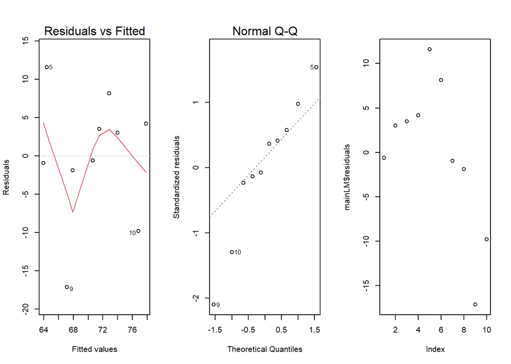

```r
par(mfrow=c(1,3))
plot(mainLM, which = 1:2)
plot(mainLM$residuals)
```

## Conclusion

While we can make an educated guess based off of the model for predicting the weather, the results can be considered questionable because of the lack of significance and concerns related to normality and constant variance.